# Lab 2: Introduction to modeling in R

Your name

2024-01-15

### **Learning Objectives**

- Understand how to construct a simple process-based model in R
- Import external data as a data frame
- Summarize the contents of a data frame
- Produce and interpret degree-day model predictions

### **Grading Rubric**

Most of your grade will be for effort - i.e., that you did your best to follow instructions and to answer questions. Each lab is worth 30 pts, so divide this number by the total number of questions to estimate the approximate number of points per question. Points may be deducted for errors in code, not following instructions, or answering questions incorrectly.

### **Instructions**

There are questions associated with each exercise below to complete either during class or on your own time. Record answers to the questions **within** the Markdown (`.Rmd`) file and record your name on line 2. Once you’re done with the lab, knit the R markdown file as a Word document (`.docx`) within RStudio by clicking the `Knit` button found in the toolbar (look for a ball of yarn with a needle sticking out of it) and selecting `Knit to Word`. Ignore any warning messages that pop up in the Console during knitting. Submit the `.Rmd` **and** the `.docx` files on Canvas.

### **Introduction**

We will develop several **process-based** models in this course. In ecology, process-based models are based on a theoretical understanding of relevant ecological processes. Relationships are described in terms of explicitly stated processes or mechanisms, and model parameters therefore have a clear ecological interpretation. An example of a process-based model in ecology includes the process of how radiation, water, and temperature affect the rate of photosynthesis. Process-based models can have a spatial and/or temporal component. For example, you could use a process-based model for photosynthesis to study how rates differ across different latitudes or how they change over the course of a year.

For this lab, you will learn how to develop a process-based model that predicts degree-day accumulation over time. **Degree-day** models are often used to predict the phenology of ectothermic organisms (poikilothermic) such as insects, plants, and fungi. These organisms require a consistent amount of heat accumulation to reach certain life stages, such as egg hatch or adult flight for insects, or leaf out and flowering in plants. A **degree-day** is a measurement of heat units over time (i.e., heat accumulation), calculated from daily maximum and minimum temperatures ($T_{max}$ and $T_{min}$, respectively). DD models typically use a daily or hourly **time step**, meaning that DDs are calculated for each day or hour, respectively. The model tracks the accumulation of these DDs over a specific time period, such as a season or an entire year.

#### **Calculating Degree-Days**

The $T_{min}$ at which an ectothermic organism begins to develop is called the “lower developmental threshold” ($LDT$), or baseline. The $T_{max}$ at which development stops is called the “upper developmental threshold ($UDT$),” or cutoff. The $LDT$ and $UDT$ vary among species, and have been determined for many economically important pests.

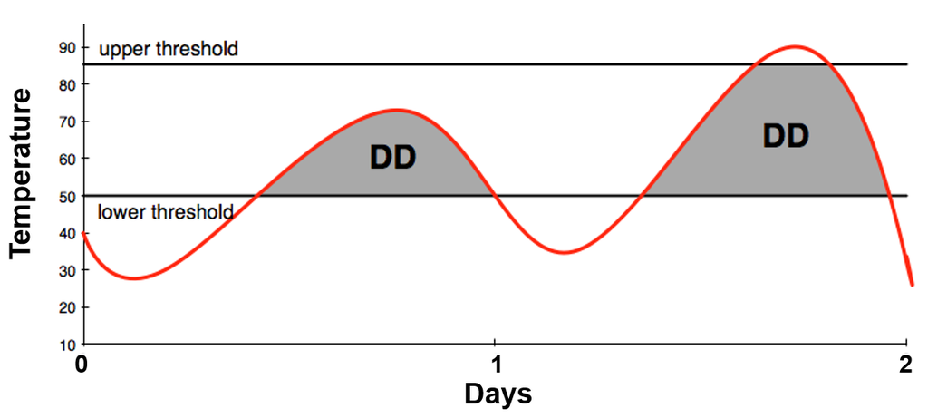

#### Degree-Day Model Assumptions

1. Temperatures of a 24-hour day follow a defined curve
2. The rate of development is presumed to be a straight line directly related to temperature

#### Simple Average

[(daily $T_{max}$ + $T_{min}$)/2] – $LDT$

For example, a day where the high is 72$^\circ$F and the low is 44$^\circ$F would accumulate 8 DDs using 50$^\circ$F as the $LDT$:

$$[(72 + 44)/2] – 50 = 8$$

For a site with $T_{max}$ and $T_{min}$ data available, the different methods for calculating DDs are single sine, double sine, single triangle, and double triangle.

### **A Simple Degree-Day Model**

#### **Lower Developmental Threshold (LDT)**

In the following exercise, we will use the simple formula to calculate DDs using a $LDT$ of 50F. This $LDT$ is commonly used in DD models for plants and insect pests. The weather data used in our model is in degrees Fahrenheit.

```r
# Lower development threshold
LDT50F  <- 50
```

**(1)** What is the class and specific data type of `LDT50F` object? Show your work in the code chunk below.

*Response*:

**(2)** Say you’re working on a species with an $LDT$ of 54F. In the code chunk below, create an object named `LDT54F` that defines this threshold.

```r
# LDT54F
#
#
```

**(3)** In the code chunk below, calculate DDs using your two thresholds, `LDT50F` and `LDT54F`. Use `80.1` and `47.5` as $T_{max}$ and $T_{min}$, respectively. Which threshold resulted in a larger DD value and why?

```r
# tmax = 80.1
# tmin = 47.5
```

*Response*:

#### **Importing and Formatting Weather Data**

```r
# Path of weather data file
weath_fl <- here("Lab2_model_building_R", "weather_data", "CRVO21.txt")
```

The weather data file is a space-delimited text file. We will import it using the [`read_table()`](https://www.rdocumentation.org/packages/readr/versions/2.1.3/topics/read_table) function from the [`readr`](https://readr.tidyverse.org/) package (part of Tidyverse). We will talk more about the Tidyverse soon. The first row is skipped using `skip` and the seventh column is skipped using `col_skip` because they contain comments rather than data. The column names are defined using the `colnames()` function in base R.

```r
# Import weather data
weath_tbl <- read_table(weath_fl, skip = 1, col_names = FALSE,
                        col_types = cols(X7 = col_skip()))
```

Next we convert the table to a data frame using the `data.frame()` function. Additionally, the `colnames()` function is used to define the column names.

```r
# Convert the table to a data frame and name the columns
weath_data <- data.frame(weath_tbl)
colnames(weath_data) <- c("month", "day", "tmax", "tmin", "prec", "dd50")
```

**(4)** In the code chunk below, use recently learned functions to get the dimensions and data structure of the weather data. Next, write code to peek at the first and last 6 rows of data. What are two things that you learned about the data set?

```r
# Dimensions

# Structure

# Head

# Tail
```

*Response*:

#### **The Daily Time Step**

The simple DD model will predict the development of a hypothetical organism in 2021. To do this, it will use a daily time step to calculate DDs for each day and accumulate these DDs over the entire year. In R, this can be accomplished using a `for loop`. First, we will specify the time period as the number of rows in the weather data.

**(5)** In the code chunk below, create an object named `number_of_days` that uses the `nrow()` function to get this information.

```r
# How many rows in the data frame?
number_of_days <- nrow(weath_data)
```